# Practical Machine Learning - Week 4

PGM

18/11/2017

### Background

Using devices such as Jawbone Up, Nike FuelBand, and Fitbit it is now possible to collect a large amount of data about personal activity relatively inexpensively. These type of devices are part of the quantified self movement – a group of enthusiasts who take measurements about themselves regularly to improve their health, to find patterns in their behavior, or because they are tech geeks. One thing that people regularly do is quantify how much of a particular activity they do, but they rarely quantify how well they do it. In this project, your goal will be to use data from accelerometers on the belt, forearm, arm, and dumbell of 6 participants. They were asked to perform barbell lifts correctly and incorrectly in 5 different ways. More information is available from the website here: http://web.archive.org/web/20161224072740/http:/groupware.les.inf.puc-rio.br/har (see the section on the Weight Lifting Exercise Dataset).

Data

The training data for this project are available here:

https://d396qusza40orc.cloudfront.net/predmachlearn/pml-training.csv

The test data are available here:

https://d396qusza40orc.cloudfront.net/predmachlearn/pml-testing.csv

The data for this project come from this source: http://web.archive.org/web/20161224072740/http:/groupware.les.inf.puc-rio.br/har. If you use the document you create for this class for any purpose please cite them as they have been very generous in allowing their data to be used for this kind of assignment.

### Cleaning data

```r
## Download the CSV files with the data
fileURL <- "https://d396qusza40orc.cloudfront.net/predmachlearn/pml-training.csv"
download.file(fileURL, destfile = "./pml-training.csv", method = "curl")
dateDownloaded <- date()

fileURL <- "https://d396qusza40orc.cloudfront.net/predmachlearn/pml-testing.csv"
download.file(fileURL, destfile = "./pml-testing.csv", method = "curl")
dateDownloaded <- date()

## Loading the data from the CSV files downloaded
pml_training <- read.csv("./pml-training.csv", sep = ",", header = TRUE)
head(pml_training)
```

```
##   X user_name raw_timestamp_part_1 raw_timestamp_part_2   cvtd_timestamp
## 1 1  carlitos           1323084231               788290 05/12/2011 11:23
## 2 2  carlitos           1323084231               808298 05/12/2011 11:23
## 3 3  carlitos           1323084231               820366 05/12/2011 11:23
## 4 4  carlitos           1323084232               120339 05/12/2011 11:23
## 5 5  carlitos           1323084232               196328 05/12/2011 11:23
## 6 6  carlitos           1323084232               304277 05/12/2011 11:23
##   new_window num_window roll_belt pitch_belt yaw_belt total_accel_belt
## 1         no         11      1.41       8.07    -94.4                3
## 2         no         11      1.41       8.07    -94.4                3
## 3         no         11      1.42       8.07    -94.4                3
## 4         no         12      1.48       8.05    -94.4                3
## 5         no         12      1.48       8.07    -94.4                3
## 6         no         12      1.45       8.06    -94.4                3
##   kurtosis_roll_belt kurtosis_picth_belt kurtosis_yaw_belt
```

[output cut: 265 more lines]

```r
pml_testing <- read.csv("./pml-testing.csv", sep = ",", header = TRUE)
head(pml_testing)
```

```
##   X user_name raw_timestamp_part_1 raw_timestamp_part_2   cvtd_timestamp
## 1 1     pedro           1323095002               868349 05/12/2011 14:23
## 2 2    jeremy           1322673067               778725 30/11/2011 17:11
## 3 3    jeremy           1322673075               342967 30/11/2011 17:11
## 4 4    adelmo           1322832789               560311 02/12/2011 13:33
## 5 5    eurico           1322489635               814776 28/11/2011 14:13
## 6 6    jeremy           1322673149               510661 30/11/2011 17:12
##   new_window num_window roll_belt pitch_belt yaw_belt total_accel_belt
## 1         no         74    123.00      27.00    -4.75               20
## 2         no        431      1.02       4.87   -88.90                4
## 3         no        439      0.87       1.82   -88.50                5
## 4         no        194    125.00     -41.60   162.00               17
## 5         no        235      1.35       3.33   -88.60                3
## 6         no        504     -5.92       1.59   -87.70                4
##   kurtosis_roll_belt kurtosis_picth_belt kurtosis_yaw_belt
```

[output cut: 265 more lines]

Search for the strings regarding the accelerometers on 4 locations (belt, forearm, arm, dumbbell)

```r
choices <- c("accel_belt", "accel_forearm", "accel_arm", "accel_dumbbell")
columns <- grepl(paste(choices, collapse = "|"), colnames(pml_training))
```

```r
# Extracting the data in those columns only
specificTraining <- pml_training[, columns]

## Removing choices and columns
rm(choices, columns)
```

Looking briefly at the resulting data:

```r
summary(specificTraining)
```

```
##  total_accel_belt var_total_accel_belt  accel_belt_x       accel_belt_y
##  Min.   : 0.00    Min.   : 0.000       Min.   :-120.000   Min.   :-69.00
##  1st Qu.: 3.00    1st Qu.: 0.100       1st Qu.: -21.000   1st Qu.:  3.00
##  Median :17.00    Median : 0.200       Median : -15.000   Median : 35.00
##  Mean   :11.31    Mean   : 0.926       Mean   :  -5.595   Mean   : 30.15
##  3rd Qu.:18.00    3rd Qu.: 0.300       3rd Qu.:  -5.000   3rd Qu.: 61.00
##  Max.   :29.00    Max.   :16.500       Max.   :  85.000   Max.   :164.00
##                   NA's   :19216
##   accel_belt_z     total_accel_arm var_accel_arm     accel_arm_x
##  Min.   :-275.00   Min.   : 1.00   Min.   :  0.00   Min.   :-404.00
##  1st Qu.:-162.00   1st Qu.:17.00   1st Qu.:  9.03   1st Qu.:-242.00
##  Median :-152.00   Median :27.00   Median : 40.61   Median : -44.00
##  Mean   : -72.59   Mean   :25.51   Mean   : 53.23   Mean   : -60.24
##  3rd Qu.:  27.00   3rd Qu.:33.00   3rd Qu.: 75.62   3rd Qu.:  84.00
##  Max.   : 105.00   Max.   :66.00   Max.   :331.70   Max.   : 437.00
##                                    NA's   :19216
##   accel_arm_y      accel_arm_z      total_accel_dumbbell
##  Min.   :-318.0   Min.   :-636.00   Min.   : 0.00
##  1st Qu.: -54.0   1st Qu.:-143.00   1st Qu.: 4.00
##  Median :  14.0   Median : -47.00   Median :10.00
##  Mean   :  32.6   Mean   : -71.25   Mean   :13.72
##  3rd Qu.: 139.0   3rd Qu.:  23.00   3rd Qu.:19.00
##  Max.   : 308.0   Max.   : 292.00   Max.   :58.00
##
##  var_accel_dumbbell accel_dumbbell_x  accel_dumbbell_y  accel_dumbbell_z
##  Min.   :  0.000    Min.   :-419.00   Min.   :-189.00   Min.   :-334.00
##  1st Qu.:  0.378    1st Qu.: -50.00   1st Qu.:  -8.00   1st Qu.:-142.00
##  Median :  1.000    Median :  -8.00   Median :  41.50   Median :  -1.00
##  Mean   :  4.388    Mean   : -28.62   Mean   :  52.63   Mean   : -38.32
##  3rd Qu.:  3.434    3rd Qu.:  11.00   3rd Qu.: 111.00   3rd Qu.:  38.00
##  Max.   :230.428    Max.   : 235.00   Max.   : 315.00   Max.   : 318.00
##  NA's   :19216
##  total_accel_forearm var_accel_forearm accel_forearm_x   accel_forearm_y
##  Min.   :  0.00      Min.   :  0.000   Min.   :-498.00   Min.   :-632.0
##  1st Qu.: 29.00      1st Qu.:  6.759   1st Qu.:-178.00   1st Qu.:  57.0
##  Median : 36.00      Median : 21.165   Median : -57.00   Median : 201.0
##  Mean   : 34.72      Mean   : 33.502   Mean   : -61.65   Mean   : 163.7
##  3rd Qu.: 41.00      3rd Qu.: 51.240   3rd Qu.:  76.00   3rd Qu.: 312.0
##  Max.   :108.00      Max.   :172.606   Max.   : 477.00   Max.   : 923.0
##                      NA's   :19216
##  accel_forearm_z
##  Min.   :-446.00
##  1st Qu.:-182.00
##  Median : -39.00
##  Mean   : -55.29
##  3rd Qu.:  26.00
##  Max.   : 291.00
##
```

The amount of NA’s is so high on the variables ‘var_accel’ & ‘var_total_accel’ from the 4 locations that it those columns will be removed from the pool of independent variables.

```r
choices <- c("var_accel", "var_total_accel")
columns <- grepl(paste(choices, collapse = "|"), colnames(specificTraining))

# Extracting the data in those columns only
specificTraining <- specificTraining[, !columns]

## Removing choices and columns
rm(choices, columns)
```

Adding the “classe” variable to the specificTraining dataset:

```r
# Adding classe
specificTraining <- cbind(specificTraining, classe = pml_training$classe)
```

### Data partition to evaluate out-of-sample errors

As the model cannot be tested with pml_testing without knowing how it performs, it is necessary to split the training data in 2 groups:

```r
library(caret)
set.seed(28322)

# Generating a possible partition (80% / 20%)
inTrain <- createDataPartition(y = specificTraining$classe, p = 0.80, list = FALSE)

# Assigning most of the data to the subtraining group and the rest to the subtesting group
subtraining  <- specificTraining[inTrain, ]
subtesting  <- specificTraining[-inTrain, ]
```

### Model development

Building a random forest model:

```r
library(randomForest)
set.seed(28322)

# Building a random forest model
modFit <- randomForest(classe ~ ., data = subtraining)
modFit
```

```
##
## Call:
##  randomForest(formula = classe ~ ., data = subtraining)
##                Type of random forest: classification
##                      Number of trees: 500
## No. of variables tried at each split: 4
##
##         OOB estimate of  error rate: 4.92%
## Confusion matrix:
##      A    B    C    D    E class.error
## A 4315   28   60   58    3  0.03337814
## B  101 2819   74   20   24  0.07208690
## C   41   62 2609   21    5  0.04711468
## D   65   13  101 2379   15  0.07539837
## E    5   32   21   24 2804  0.02841303
```

Showing the results visually for the iterations made during the model creation:

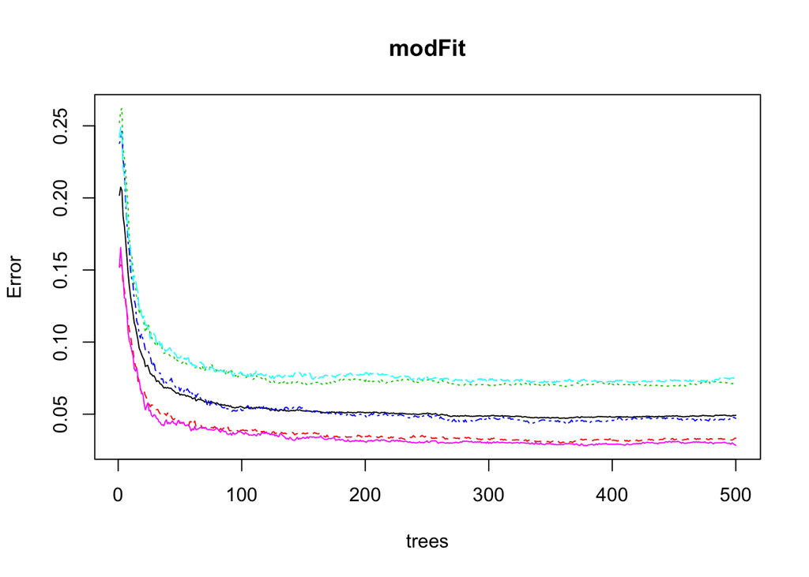

```r
plot(modFit)
```

Dotchart of variable importance as measured by the random forest model just created:

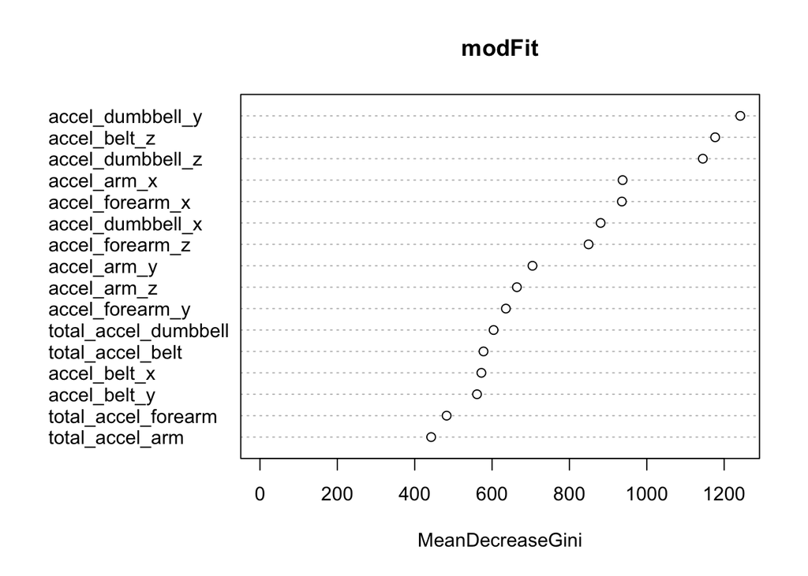

```r
varImpPlot(modFit)
```

### Application of model to subtesting dataset

Predicting the classe values for subtesting:

```r
# A variable classe is added to the testing dataset with the predictions
prediction <- predict(modFit, newdata = subtesting)

# Creating the confusion matrix for the results achieved
confusion <- confusionMatrix(prediction, subtesting$classe)
confusion
```

```
## Confusion Matrix and Statistics
##
##           Reference
## Prediction    A    B    C    D    E
##          A 1071   32   10   10    1
##          B   11  701   19    2    5
##          C   15   22  640   27    5
##          D   18    1   11  603    5
##          E    1    3    4    1  705
##
## Overall Statistics
##
##                Accuracy : 0.9483
##                  95% CI : (0.9409, 0.955)
##     No Information Rate : 0.2845
##     P-Value [Acc > NIR] : < 2.2e-16
##
##                   Kappa : 0.9345
##  Mcnemar's Test P-Value : 0.007316
##
## Statistics by Class:
##
##                      Class: A Class: B Class: C Class: D Class: E
## Sensitivity            0.9597   0.9236   0.9357   0.9378   0.9778
## Specificity            0.9811   0.9883   0.9787   0.9893   0.9972
## Pos Pred Value         0.9528   0.9499   0.9027   0.9451   0.9874
## Neg Pred Value         0.9839   0.9818   0.9863   0.9878   0.9950
## Prevalence             0.2845   0.1935   0.1744   0.1639   0.1838
## Detection Rate         0.2730   0.1787   0.1631   0.1537   0.1797
## Detection Prevalence   0.2865   0.1881   0.1807   0.1626   0.1820
## Balanced Accuracy      0.9704   0.9559   0.9572   0.9636   0.9875
```

Accuracy of 94.83%, so that seems interesting.

From this result, it is possible to have a reference of the performance from the calculated model:

```r
out_of_sample_error <- 1 - confusion$overall[1]
names(out_of_sample_error) <- "Error"
out_of_sample_error
```

```
##      Error
## 0.05174611
```

### Application of model to global testing dataset

Predicting the classe values for pml_testing:

```r
# A variable classe is added to the testing dataset with the predictions
pml_testing$classe <- predict(modFit, newdata = pml_testing)

# The predictions to be provider to the automatic checker
pml_testing$classe
```

```
##  [1] B A C A A E D B A A B C B A E E A B B B
## Levels: A B C D E
```